# **HW1**

## *Şiar Bozyer*

http://localhost:8889/notebooks/HW1.ipynb#

The data is taken from https://www.football-data.co.uk/englandm.php. My work is about Premier Leagues's last 3 seasons (2018-2019, 2019-2020, 2020-2021), then I combined these datasets.

```r
library(data.table)
data2020_2021 <- read.csv("https://www.football-data.co.uk/mmz4281/2021/E0.csv",TRUE,",")
data2019_2020 <- read.csv("https://www.football-data.co.uk/mmz4281/1920/E0.csv",TRUE,",")
data2018_2019 <- read.csv("https://www.football-data.co.uk/mmz4281/1819/E0.csv",TRUE,",")

a=list(data2020_2021,data2019_2020,data2018_2019)

premier<-rbindlist(a,fill = T)
```

### Task 1.1

The histograms of home, away goals and the differences between them are:

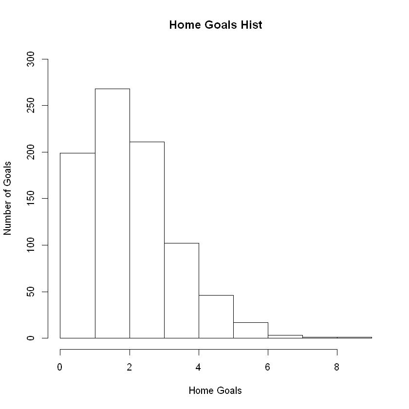

```r
hist(premier$FTHG,ylim = c(0,300),right = FALSE,
     breaks = seq(from = 0, to = max(premier$FTHG)+1, by=1),xlab = "Home Goals",
     main = "Home Goals Hist", ylab = "Number of Goals")
```

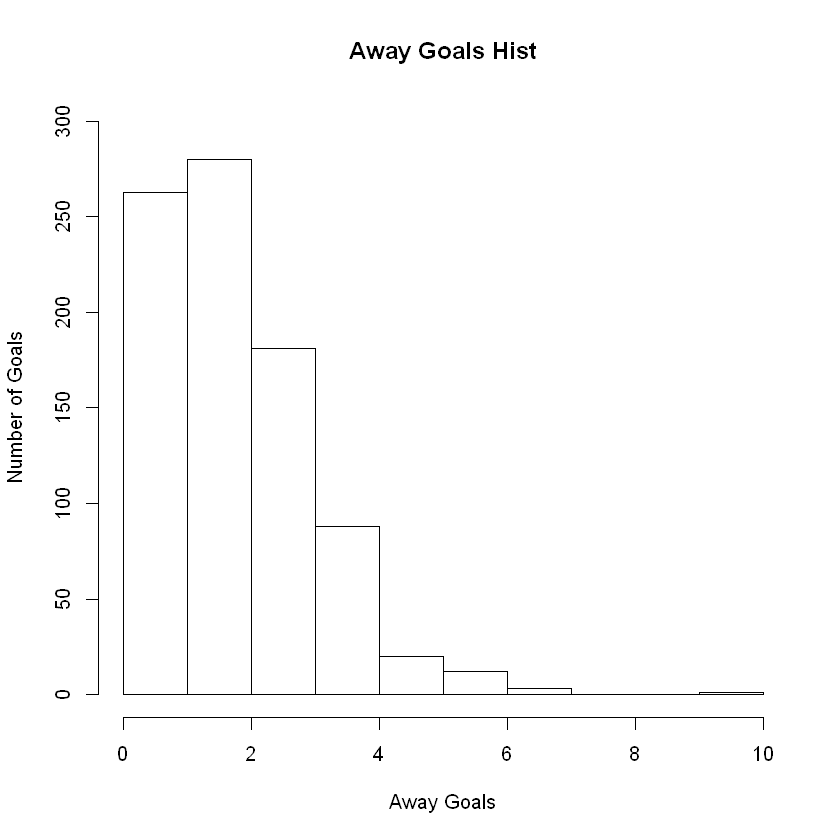

```r
hist(premier$FTAG,ylim = c(0,300),right = FALSE,
     breaks = seq(from = 0, to = max(premier$FTAG)+1, by=1),xlab = "Away Goals",
     main = "Away Goals Hist", ylab = "Number of Goals")
```

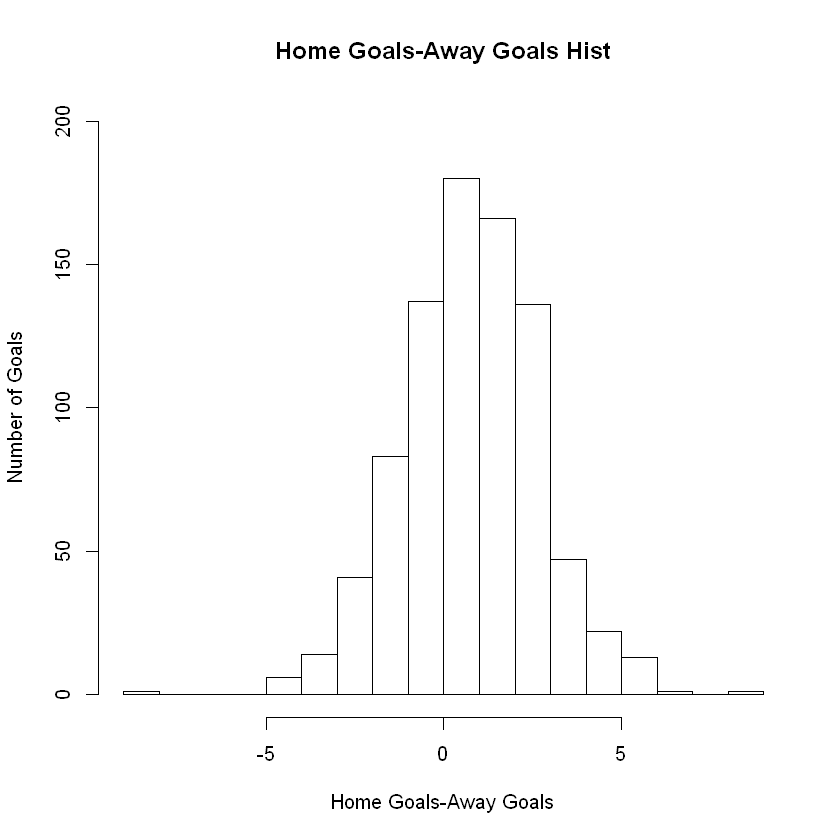

```r
difference <- premier$FTHG-premier$FTAG

hist(difference,ylim = c(0,200),right = FALSE,
     breaks = seq(from = min(difference), to = max(difference)+1, by=1),,xlab = "Home Goals-Away Goals",
     main = "Home Goals-Away Goals Hist", ylab = "Number of Goals")
```

### Task 1.2

As you see below, Poisson distribution firstly increases then in some point, it decreases generally. Our histograms for home and away goals have also similar shapes. Therefore, we can say graphically that home and away goals fit the Poisson Distribution.

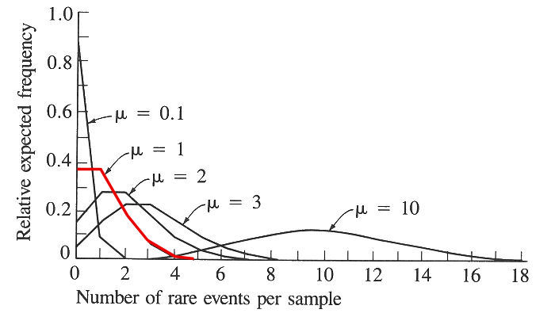

I plot poisson distributions on home goals and away goals histograms with the mean of these datasets.

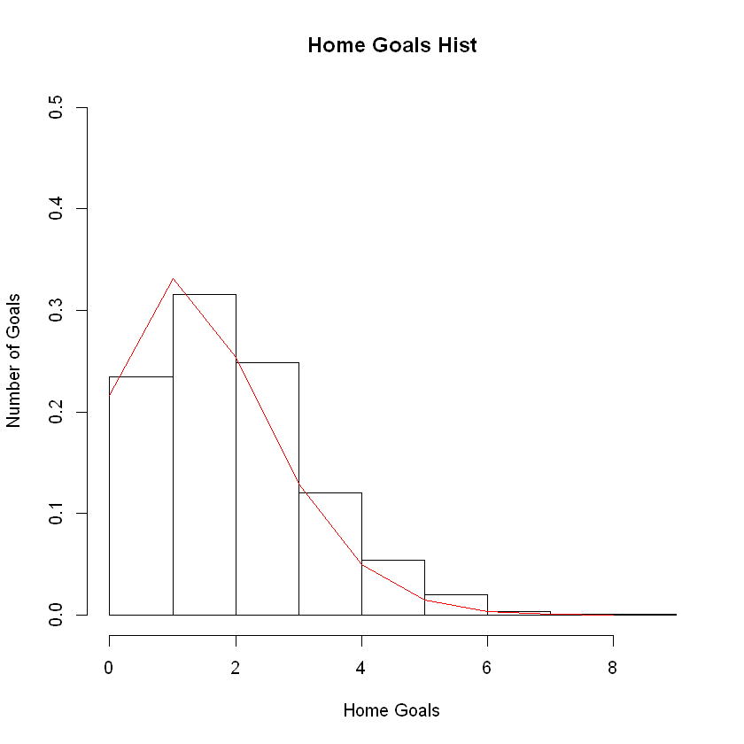

```r
xfit_FTHG <- (0:max(premier$FTHG))

yfit_FTHG <- dpois(xfit_FTHG,lambda = mean(premier$FTHG))


hist(premier$FTHG,prob=T,ylim = c(0,0.5),right = FALSE,
     breaks = seq(from = 0, to = max(premier$FTHG)+1, by=1),xlab = "Home Goals",
     main = "Home Goals Hist", ylab = "Number of Goals")
lines(xfit_FTHG,yfit_FTHG,col="red")
```

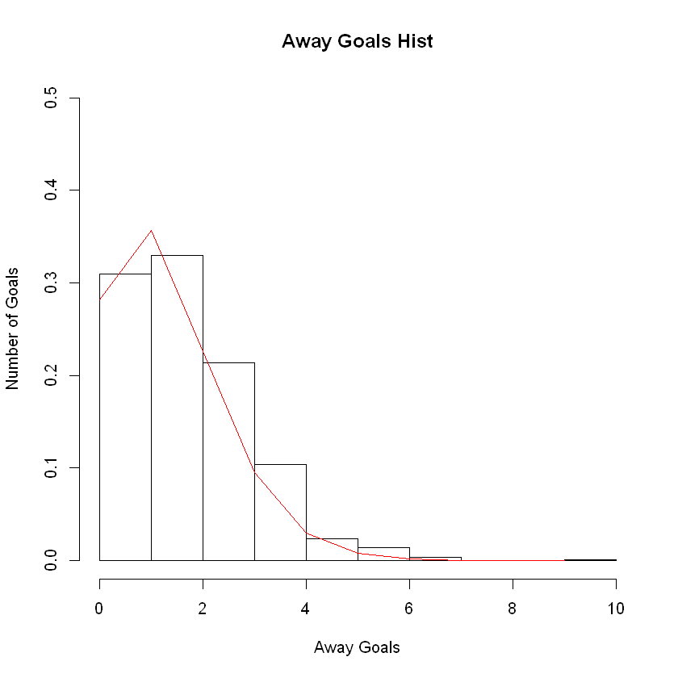

```r
xfit_FTAG <- (0:max(premier$FTAG))

yfit_FTAG <- dpois(xfit_FTAG,lambda = mean(premier$FTAG))


hist(premier$FTAG,prob=T,ylim = c(0,0.5),right = FALSE,
     breaks = seq(from = 0, to = max(premier$FTAG)+1, by=1),xlab = "Away Goals",
     main = "Away Goals Hist", ylab = "Number of Goals")
lines(xfit_FTAG,yfit_FTAG,col="red")
```

### Task 2.1 and 2.2

I use Bet365, BetAndWin, Some Bookmarkers (IW) and Pinnacle bet ratios. I find probabilities from odds by using Probability = 1/odd formulation. For normalization formula that I use is below.

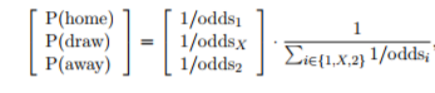

.

```r
#B365
B365_HomeWin = 1 / premier$B365H
B365_Tie = 1 / premier$B365D
B365_AwayWin = 1 / premier$B365A

#BW
BW_HomeWin = 1 / premier$BWH
BW_Tie = 1 / premier$BWD
BW_AwayWin = 1 / premier$BWA

#IW
IW_HomeWin = 1 / premier$IWH
IW_Tie = 1 / premier$IWD
IW_AwayWin = 1 / premier$IWA

#PS
PS_HomeWin = 1 / premier$PSH
PS_Tie = 1 / premier$PSD
PS_AwayWin = 1 / premier$PSA

#B365
B365_HomeWin_Norm = B365_HomeWin / (B365_HomeWin+B365_AwayWin+B365_Tie)
B365_Tie_Norm = B365_Tie / (B365_HomeWin+B365_AwayWin+B365_Tie)
B365_AwayWin_Norm = B365_AwayWin / (B365_HomeWin+B365_AwayWin+B365_Tie)

#BW
BW_HomeWin_Norm = BW_HomeWin / (BW_HomeWin+BW_AwayWin+BW_Tie)
BW_Tie_Norm = BW_Tie / (BW_HomeWin+BW_AwayWin+BW_Tie)
BW_AwayWin_Norm = BW_AwayWin / (BW_HomeWin+BW_AwayWin+BW_Tie)

#IW
IW_HomeWin_Norm = IW_HomeWin / (IW_HomeWin+IW_AwayWin+IW_Tie)
IW_Tie_Norm = IW_Tie / (IW_HomeWin+IW_AwayWin+IW_Tie)
IW_AwayWin_Norm = IW_AwayWin / (IW_HomeWin+IW_AwayWin+IW_Tie)

#PS
PS_HomeWin_Norm = PS_HomeWin / (PS_HomeWin+PS_AwayWin+PS_Tie)
PS_Tie_Norm = PS_Tie / (PS_HomeWin+PS_AwayWin+PS_Tie)
PS_AwayWin_Norm = PS_AwayWin / (PS_HomeWin+PS_AwayWin+PS_Tie)
```

### Task 2.3 and 2.4

Normalized probabilities are calculated above. I plot to normalized data with P(home win) – P(away win) on x-axis and P (tie) on y-axis. Then I find actual probabilities into bins (i.e. (-1,-0.8], (-0.8, -0.6], …, (0.8,1]) by dividing draw results and normalized probability of Home Win - Away Win by normalized probability of Home Win - Away and draw result between bin limits. I applied all odd companies that I choose (Bet365, BetAndWin, Some Bookmarkers (IW) and Pinnacle). Plots are below:

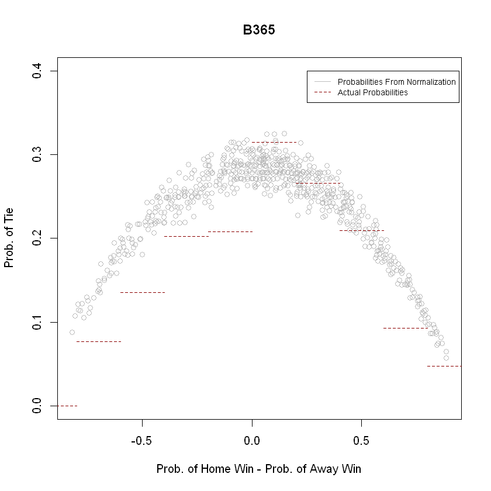

```r
x=B365_HomeWin_Norm - B365_AwayWin_Norm
y=B365_Tie_Norm
premier$B365HWN = x

z=matrix(nrow=10,ncol=4)

j=1
for (i in seq (-0.8,1,0.2)){
        z[j,1]=sum(premier$B365HWN<=i & premier$B365HWN>i-0.2)
        z[j,2]=sum(premier$B365HWN<=i & premier$B365HWN>i-0.2 & premier$FTR=='D')
        z[j,3]=z[j,2]/z[j,1]
        z[j,4]=i
        j=j+1
}

plot(x,y, ylim = c(0,0.4),col = 'gray',xlab = 'Prob. of Home Win - Prob. of Away Win',
     ylab = 'Prob. of Tie', main = 'B365',lty=1)
for (i in 1:10){
        segments(x0=z[i,4]-0.2,x1=z[i,4],y0=z[i,3],y1=z[i,3],col = 'dark red',lty=2)
}
legend(x=0.25, y= 0.4, legend = c("Probabilities From Normalization","Actual Probabilities"),
       col = c("gray","dark red"),lty = 1:2,cex = 0.7)
```

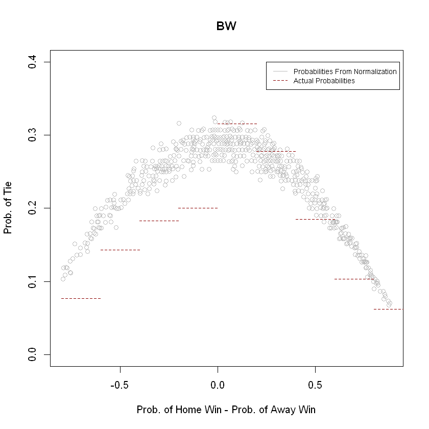

```r
x=BW_HomeWin_Norm - BW_AwayWin_Norm
y=BW_Tie_Norm
premier$BWHWN = x

z=matrix(nrow=10,ncol=4)

j=1
for (i in seq (-0.8,1,0.2)){
        z[j,1]=sum(premier$BWHWN<=i & premier$BWHWN>i-0.2)
        z[j,2]=sum(premier$BWHWN<=i & premier$BWHWN>i-0.2 & premier$FTR=='D')
        z[j,3]=z[j,2]/z[j,1]
        z[j,4]=i
        j=j+1
}

plot(x,y, ylim = c(0,0.4),col = 'gray',xlab = 'Prob. of Home Win - Prob. of Away Win',
     ylab = 'Prob. of Tie', main = 'BW',lty=1)
for (i in 1:10){
        segments(x0=z[i,4]-0.2,x1=z[i,4],y0=z[i,3],y1=z[i,3],col = 'dark red',lty=2)
}
legend(x=0.25, y= 0.4, legend = c("Probabilities From Normalization","Actual Probabilities"),
       col = c("gray","dark red"),lty = 1:2,cex = 0.7)
```

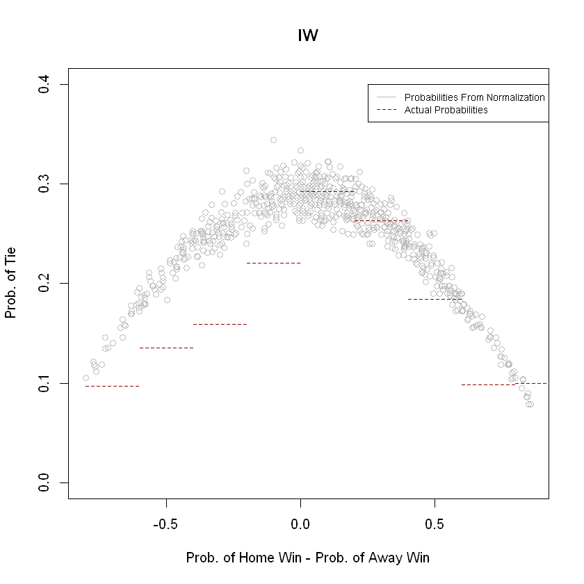

```r
x=IW_HomeWin_Norm - IW_AwayWin_Norm
y=IW_Tie_Norm
premier$IWHWN = x

z=matrix(nrow=10,ncol=4)

j=1
for (i in seq (-0.8,1,0.2)){
        z[j,1]=sum(premier$IWHWN<=i & premier$IWHWN>i-0.2)
        z[j,2]=sum(premier$IWHWN<=i & premier$IWHWN>i-0.2 & premier$FTR=='D')
        z[j,3]=z[j,2]/z[j,1]
        z[j,4]=i
        j=j+1
}

plot(x,y, ylim = c(0,0.4),col = 'gray',xlab = 'Prob. of Home Win - Prob. of Away Win',
     ylab = 'Prob. of Tie', main = 'IW',lty=1)
for (i in 1:10){
        segments(x0=z[i,4]-0.2,x1=z[i,4],y0=z[i,3],y1=z[i,3],col = 'dark red',lty=2)
}
legend(x=0.25, y= 0.4, legend = c("Probabilities From Normalization","Actual Probabilities"),
       col = c("gray","dark red"),lty = 1:2,cex = 0.7)
```

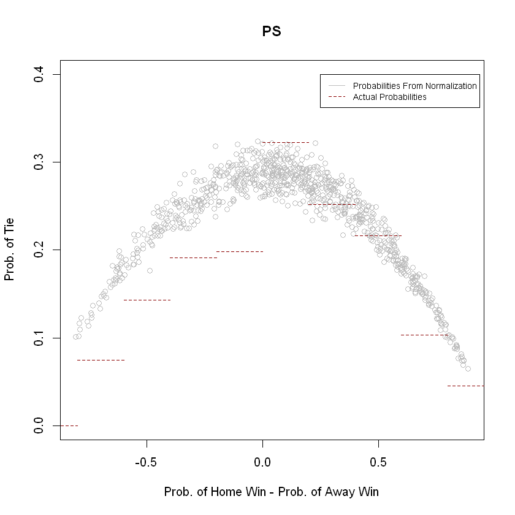

```r
x=PS_HomeWin_Norm - PS_AwayWin_Norm
y=PS_Tie_Norm
premier$PSHWN = x

z=matrix(nrow=10,ncol=4)

j=1
for (i in seq (-0.8,1,0.2)){
        z[j,1]=sum(premier$PSHWN<=i & premier$PSHWN>i-0.2)
        z[j,2]=sum(premier$PSHWN<=i & premier$PSHWN>i-0.2 & premier$FTR=='D')
        z[j,3]=z[j,2]/z[j,1]
        z[j,4]=i
        j=j+1
}

plot(x,y, ylim = c(0,0.4),col = 'gray',xlab = 'Prob. of Home Win - Prob. of Away Win',
     ylab = 'Prob. of Tie', main = 'PS',lty=1)
for (i in 1:10){
        segments(x0=z[i,4]-0.2,x1=z[i,4],y0=z[i,3],y1=z[i,3],col = 'dark red',lty=2)
}
legend(x=0.25, y= 0.4, legend = c("Probabilities From Normalization","Actual Probabilities"),
       col = c("gray","dark red"),lty = 1:2,cex = 0.7)
```

### Task 3

My filter is HR+AR = 0, and I apply Task 2 again for my new dataset. I observe that new shapes and actual values does not change dramatically.

```r
premier = premier[premier$AR + premier$HR == 0,]
#B365
B365_HomeWin = 1 / premier$B365H
B365_Tie = 1 / premier$B365D
B365_AwayWin = 1 / premier$B365A

#BW
BW_HomeWin = 1 / premier$BWH
BW_Tie = 1 / premier$BWD
BW_AwayWin = 1 / premier$BWA

#IW
IW_HomeWin = 1 / premier$IWH
IW_Tie = 1 / premier$IWD
IW_AwayWin = 1 / premier$IWA

#PS
PS_HomeWin = 1 / premier$PSH
PS_Tie = 1 / premier$PSD
PS_AwayWin = 1 / premier$PSA

#B365
B365_HomeWin_Norm = B365_HomeWin / (B365_HomeWin+B365_AwayWin+B365_Tie)
B365_Tie_Norm = B365_Tie / (B365_HomeWin+B365_AwayWin+B365_Tie)
B365_AwayWin_Norm = B365_AwayWin / (B365_HomeWin+B365_AwayWin+B365_Tie)

#BW
BW_HomeWin_Norm = BW_HomeWin / (BW_HomeWin+BW_AwayWin+BW_Tie)
BW_Tie_Norm = BW_Tie / (BW_HomeWin+BW_AwayWin+BW_Tie)
BW_AwayWin_Norm = BW_AwayWin / (BW_HomeWin+BW_AwayWin+BW_Tie)

#IW
IW_HomeWin_Norm = IW_HomeWin / (IW_HomeWin+IW_AwayWin+IW_Tie)
IW_Tie_Norm = IW_Tie / (IW_HomeWin+IW_AwayWin+IW_Tie)
IW_AwayWin_Norm = IW_AwayWin / (IW_HomeWin+IW_AwayWin+IW_Tie)

#PS
PS_HomeWin_Norm = PS_HomeWin / (PS_HomeWin+PS_AwayWin+PS_Tie)
PS_Tie_Norm = PS_Tie / (PS_HomeWin+PS_AwayWin+PS_Tie)
PS_AwayWin_Norm = PS_AwayWin / (PS_HomeWin+PS_AwayWin+PS_Tie)
```

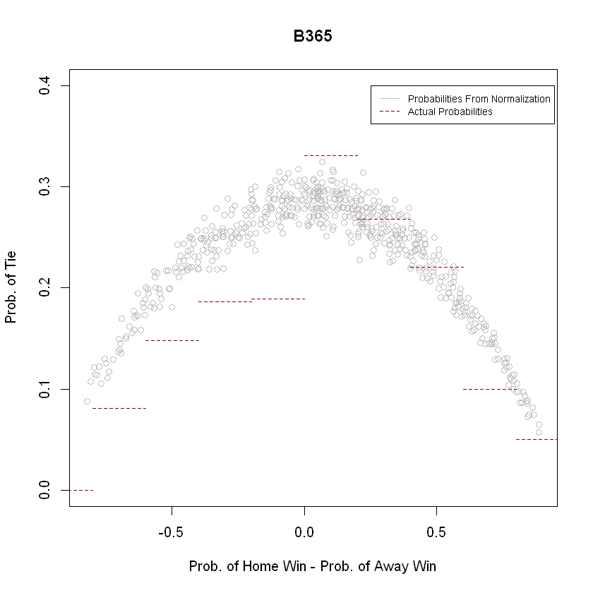

```r
x=B365_HomeWin_Norm - B365_AwayWin_Norm
y=B365_Tie_Norm
premier$B365HWN = x

z=matrix(nrow=10,ncol=4)

j=1
for (i in seq (-0.8,1,0.2)){
        z[j,1]=sum(premier$B365HWN<=i & premier$B365HWN>i-0.2)
        z[j,2]=sum(premier$B365HWN<=i & premier$B365HWN>i-0.2 & premier$FTR=='D')
        z[j,3]=z[j,2]/z[j,1]
        z[j,4]=i
        j=j+1
}

plot(x,y, ylim = c(0,0.4),col = 'gray',xlab = 'Prob. of Home Win - Prob. of Away Win',
     ylab = 'Prob. of Tie', main = 'B365',lty=1)
for (i in 1:10){
        segments(x0=z[i,4]-0.2,x1=z[i,4],y0=z[i,3],y1=z[i,3],col = 'dark red',lty=2)
}
legend(x=0.25, y= 0.4, legend = c("Probabilities From Normalization","Actual Probabilities"),
       col = c("gray","dark red"),lty = 1:2,cex = 0.7)
```

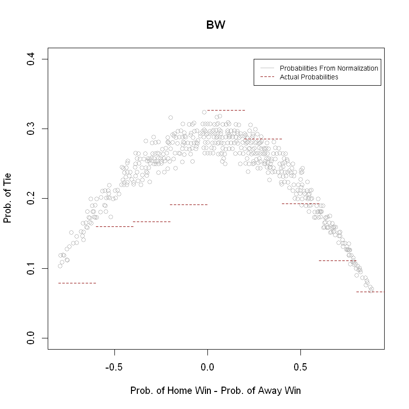

```r
x=BW_HomeWin_Norm - BW_AwayWin_Norm
y=BW_Tie_Norm
premier$BWHWN = x

z=matrix(nrow=10,ncol=4)

j=1
for (i in seq (-0.8,1,0.2)){
        z[j,1]=sum(premier$BWHWN<=i & premier$BWHWN>i-0.2)
        z[j,2]=sum(premier$BWHWN<=i & premier$BWHWN>i-0.2 & premier$FTR=='D')
        z[j,3]=z[j,2]/z[j,1]
        z[j,4]=i
        j=j+1
}

plot(x,y, ylim = c(0,0.4),col = 'gray',xlab = 'Prob. of Home Win - Prob. of Away Win',
     ylab = 'Prob. of Tie', main = 'BW',lty=1)
for (i in 1:10){
        segments(x0=z[i,4]-0.2,x1=z[i,4],y0=z[i,3],y1=z[i,3],col = 'dark red',lty=2)
}
legend(x=0.25, y= 0.4, legend = c("Probabilities From Normalization","Actual Probabilities"),
       col = c("gray","dark red"),lty = 1:2,cex = 0.7)
```

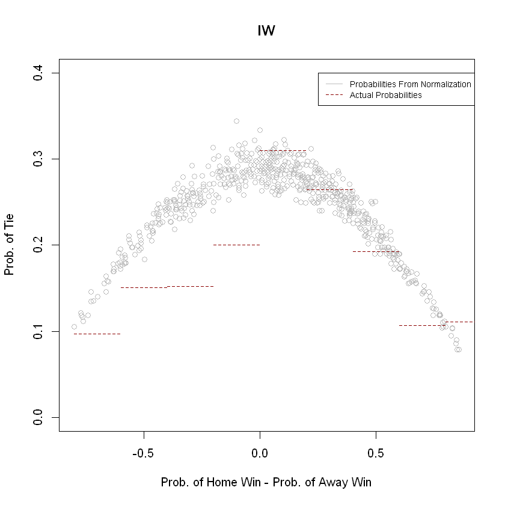

```r
x=IW_HomeWin_Norm - IW_AwayWin_Norm
y=IW_Tie_Norm
premier$IWHWN = x

z=matrix(nrow=10,ncol=4)

j=1
for (i in seq (-0.8,1,0.2)){
        z[j,1]=sum(premier$IWHWN<=i & premier$IWHWN>i-0.2)
        z[j,2]=sum(premier$IWHWN<=i & premier$IWHWN>i-0.2 & premier$FTR=='D')
        z[j,3]=z[j,2]/z[j,1]
        z[j,4]=i
        j=j+1
}

plot(x,y, ylim = c(0,0.4),col = 'gray',xlab = 'Prob. of Home Win - Prob. of Away Win',
     ylab = 'Prob. of Tie', main = 'IW',lty=1)
for (i in 1:10){
        segments(x0=z[i,4]-0.2,x1=z[i,4],y0=z[i,3],y1=z[i,3],col = 'dark red',lty=2)
}
legend(x=0.25, y= 0.4, legend = c("Probabilities From Normalization","Actual Probabilities"),
       col = c("gray","dark red"),lty = 1:2,cex = 0.7)
```

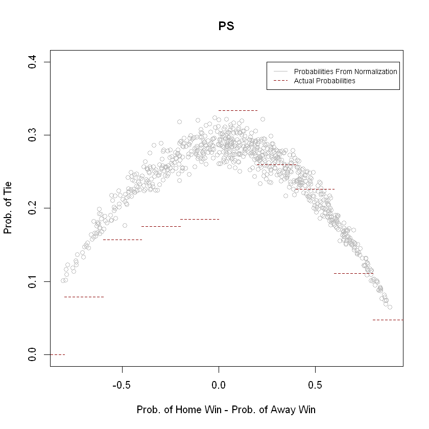

```r
x=PS_HomeWin_Norm - PS_AwayWin_Norm
y=PS_Tie_Norm
premier$PSHWN = x

z=matrix(nrow=10,ncol=4)

j=1
for (i in seq (-0.8,1,0.2)){
        z[j,1]=sum(premier$PSHWN<=i & premier$PSHWN>i-0.2)
        z[j,2]=sum(premier$PSHWN<=i & premier$PSHWN>i-0.2 & premier$FTR=='D')
        z[j,3]=z[j,2]/z[j,1]
        z[j,4]=i
        j=j+1
}

plot(x,y, ylim = c(0,0.4),col = 'gray',xlab = 'Prob. of Home Win - Prob. of Away Win',
     ylab = 'Prob. of Tie', main = 'PS',lty=1)
for (i in 1:10){
        segments(x0=z[i,4]-0.2,x1=z[i,4],y0=z[i,3],y1=z[i,3],col = 'dark red',lty=2)
}
legend(x=0.25, y= 0.4, legend = c("Probabilities From Normalization","Actual Probabilities"),
       col = c("gray","dark red"),lty = 1:2,cex = 0.7)
```